# Session 5, Automation in R

I will use previous session examples to show how to present these in Rmarkdown Rmarkdown can be found here https://rmarkdown.rstudio.com/, with cheatsheet here https://www.rstudio.com/wp-content/uploads/2015/02/rmarkdown-cheatsheet.pdf Rmarkdown provides a way to effectively communicate your code to stakeholders in a reproducible manner, you can choose how much code you want people to see. Have a play around with this Rmarkdown document, make sure all code is pointing at the correct data then add/subtract various chunk code to see how everything changes.

To start an Rmarkdown document of your own open an R script then save it with the .Rmd extension, like this script To output a html document, notice the “output: html_document” code above. To output,press on knit at the top of this screen , and then knit to HTML. You should be taken to another screen and see something similar to the output provided as a HTML document in the learning materials. To run individual code chunks, click on the green arrow in the top right hand corner of the grey boxes. You can use this to test you code chunks before knitting.

You can use “```” to start a code chunk, then control what the viewer sees. You have to start each code chuck with the code type you start with, either r, python etc.

```r
library(rmarkdown)
library(ggplot2)
library(knitr)
library(reticulate)
```

If I wanted to use another language I would have to define the language in the top line and have the reticulate package installed (for python) - this will not always work on government laptops as there is a possibility you do not have access to python

# Use Hash’s to

## Develop different

### Title sizes

If I didn’t want the viewer to see the code I would have used include = FALSE in the top line

We will now repeat some of the visualisations from session 3 and 4 to take a look at the all rounder data, but this time, use Rmarkdown to make the data presentable to an audience (with some code that might be useful when packaging this up)

```r
setwd("C:/Users/lby76f/Desktop/Teaching/Session 1")
all_rounders<-read.csv("All_rounders.csv", header=TRUE, row.names = 1)
all_rounders$hun<-ifelse(all_rounders$Hundreds == 0, 'No', 'Yes')
all_rounders$average_bin<-ifelse(all_rounders$Ave.1 < 25, "Bowling average under 25",
                                 ifelse(all_rounders$Ave.1 < 30, "Bowling average 25-30",
                                        ifelse(all_rounders$Ave.1 < 35, "Bowling average 30-35", "Bowling average over 35")))
```

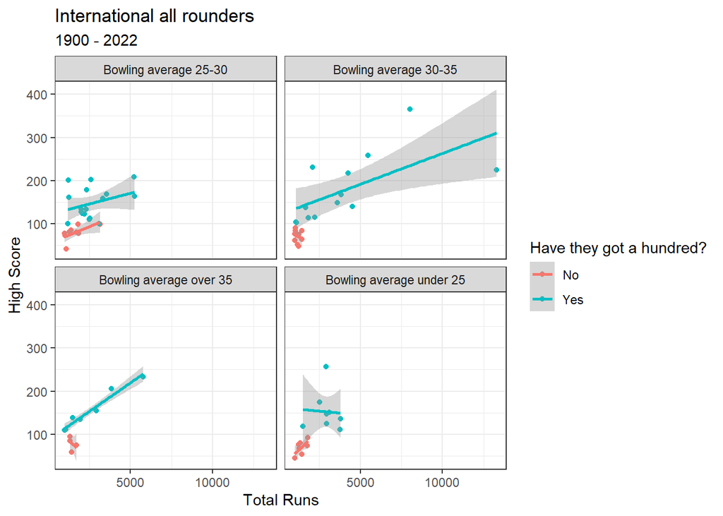

All rounders 1900-2022 seperated by bowling average

## Data Science output

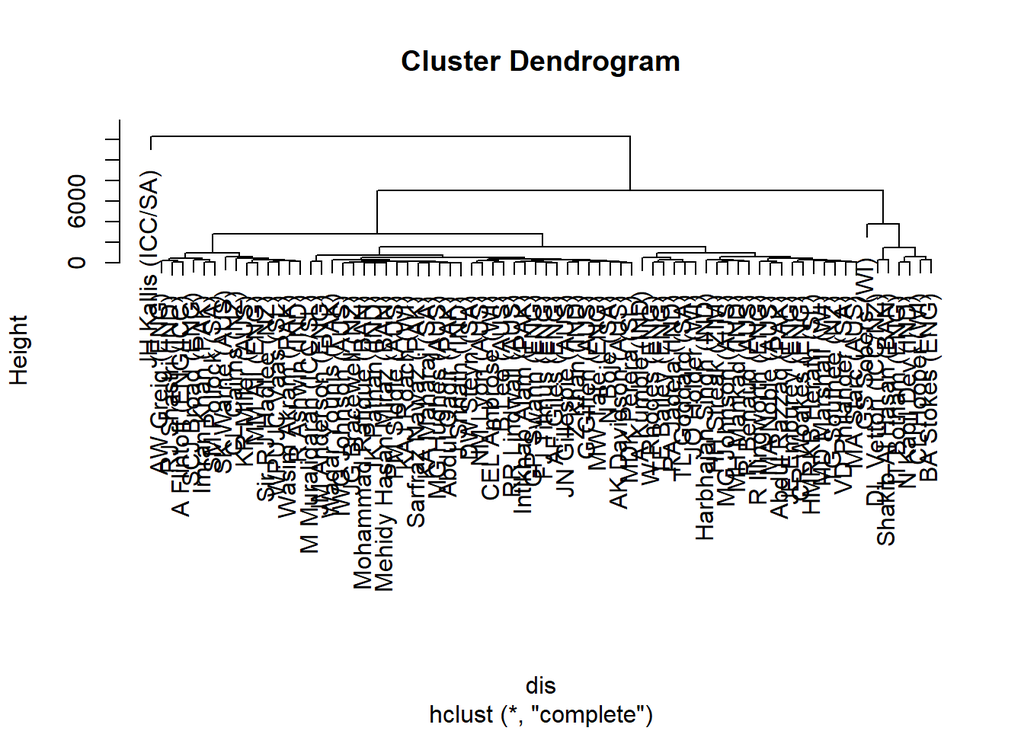

Hierarchial clustering

```r
dis<-dist(all_rounders[-c(9, 10)], method="euclidean")
clus<-hclust(dis)
plot(clus)
```

## PCA

```
## Importance of components:
##                           PC1    PC2    PC3     PC4     PC5
## Standard deviation     1.5478 1.2651 0.8444 0.45737 0.28582
## Proportion of Variance 0.4791 0.3201 0.1426 0.04184 0.01634
## Cumulative Proportion  0.4791 0.7992 0.9418 0.98366 1.00000
```

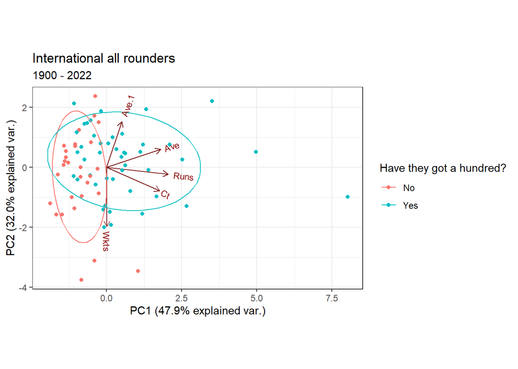

PCA for all rounders

## Rendering output

At the end of your code you can knit your Rmarkdown files to a hmtl or pdf using the button on the top left or call the rmarkdown::render function in the console

## Summary

Have a play around with Rmarkdown but hopefully you can see how it would be useful when communicating and creating professional looking documents that include your code. I tend to develop my code in development scripts before making it official in an Rmarkdown document - this way my analysis can be easily repeated with different data while keeping the formatting and analysis consistent between experiments.